# Lecture 22

## Locating Web Elements by `find_element()`

### `find_element(By.ID, "")`

- (1)
- (2)
- `find_element(By.ID, "")` & `find_elements(By.ID, "")`:
  - Return element(s) that have matching ID attribute values.
- Here is the HTML code for main part of the web-page with an ID attribute value defined as `form1`:

```html
<form id="form1">...</form>
```

- Here is an example that uses the `find_element(By.ID, "")` method to find the form table.

```python
form = driver.find_element(By.ID, "form1")
form.text  # text attribute if there is any
```

## Locating Web Elements by `find_element()`

### `find_element(By.CLASS_NAME, "")`

- (1)
- (2)
- `find_element(By.CLASS_NAME, "")` & `find_elements(By.CLASS_NAME, "")`:
  - Return element(s) that have matching class attribute value(s).
- Here is the HTML code for the home button with a class attribute value defined as `homebtn`:

```html
<div class="homebtn" align="center">...</div>
```

- Here is an example that uses the `find_element(By.CLASS_NAME, "")` method to find the home button.

```python
home_button = driver.find_element(By.CLASS_NAME, "homebtn")
home_button.click() # click the home_button object
driver.back() # back to the previous page
```

## Locating Web Elements by `find_element()`

### `find_element(By.NAME, "")`

- (1)
- (2)
- `find_element(By.NAME, "")` & `find_elements(By.NAME, "")`:
  - Return element(s) that have matching name attribute value(s).
- Here is the HTML code for the home button with a name attribute value defined as `home`:

```html
<input type="button" class="btn" name="home" value="Home" />
```

- Here is an example that uses the `find_element(By.NAME, "")` method to find the home button.

```python
home_button2 = driver.find_element(By.NAME, "home")
home_button2.click()
driver.back()
```

## Locating Web Elements by `find_element()`

### `find_element(By.CSS_SELECTOR, "")`

- (1)
- (2)
- `find_element(By.CSS_SELECTOR, "")` & `find_elements(By.CSS_SELECTOR, "")`:
  - Return element(s) that are found by the specified CSS selector.
- To find the CSS selector of the search button, we `Inspect` the example site, in the *Elements* window, move the cursor over its DOM structure and find the search element.
  - We then right-click and choose *Copy Selector* from the pop-up menu.
  - We obtain the following CSS selector of this element:

```python
home_button3 = driver.find_element(By.CSS_SELECTOR, "body > div > a > input")
home_button3.click()
driver.back()
```

## Locating Web Elements by `find_element()`

### `find_element(By.TAG_NAME, "")`

- (1)
- (2)
- (3)
- `find_element(By.TAG_NAME, "")` & `find_elements(By.TAG_NAME, "")`:
  - Return element(s) that are found by the specified tag.
- The following example page displays a table which has several form fields to fill in.
  - Each form field name is implemented using an `<th>` or table header cell tag inside a `<tr>` or table row tag:

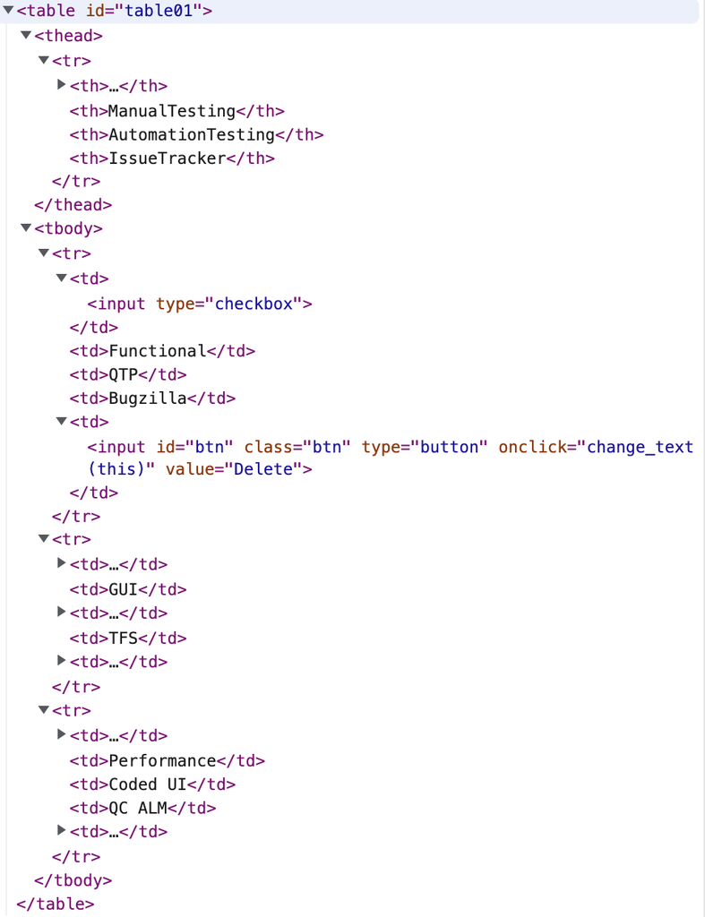

- Here is an example that uses the `find_element(By.TAG_NAME, "")` method to find the head of the table.

```python
table01 = driver.find_element(By.ID, "table01")
thead = table01.find_element(By.TAG_NAME, "thead")
thead.text
```

## Locating Web Elements by `find_element()`

### `find_element(By.LINK_TEXT, "")`

- (1)
- (2)
- (3)
- `find_element(By.LINK_TEXT, "")` & `find_elements(By.LINK_TEXT, "")`:
  - Find link(s) using the text displayed for the link.
- For example, we may want to get the **Selenium** displayed on the example site.
  - Here is the HTML code for the **Selenium** implemented as the `<a>`, or anchor tag, with text **“Selenium”**:

```html
<a href="http://www.selenium.dev/">Selenium</a>
```

- Here is an example that uses the `find_element(By.LINK_TEXT, "")` method to find **Selenium**.

```python
selenium_link = driver.find_element(By.LINK_TEXT, "Selenium")
selenium_link.click()
```

## Locating Web Elements by `find_element()`

### `find_element(By.PARTIAL_LINK_TEXT, "")`

- (1)
- (2)
- Sometimes, there can be several link texts that contain a common word in the webpage.
- `find_element(By.PARTIAL_LINK_TEXT, "")` & `find_elements(By.PARTIAL_LINK_TEXT, "")`:
  - Find link(s) using partial text.
- Let us use this method to find these links using the `"qav"` text and check whether we have two of these links available on the page.

```python
Selen_links = driver.find_elements(By.PARTIAL_LINK_TEXT, "qav")
print(len(Selen_links))
Selen_links[0].click()
driver.back()
```

## Locating Web Elements by `find_element()`

### `find_element(By.XPATH, "")`

- (1)
- (2)
- (3)
- (4)
- (5)
- (6)
- (7)
- `find_element(By.XPATH, "")` & `find_elements(By.XPATH, "")`:
  - Return element(s) that are found by the specified XPath query.
- XPath is a query language used to search and locate nodes in a XML document.
  - All major web browsers support XPath.
  - Selenium can leverage and use powerful XPath queries to find elements on a web page.
  - One of the advantages of using XPath is when we can’t find a suitable ID, name, or class attribute value for the element.

Basic Xpath Syntax

```html
//tag_name[@attribute=’value’]
```

- `//`: Stands current node
- `tag_name`: HTML tag name example `input`, `div`, `span`, etc.
- `@attribute`: Name of the attribute `class`, `id`, `aria-label`, etc.
- `value`: value of the attribute
- We can use *XPath* to either find the element in *absolute* terms (*full XPath*) or *relative* to an element that does have an ID or name attribute.
- We can also use defined attributes other than the ID, name, or class with *XPath* queries.
- For example, we want to get the second table.
  - The body of this table consists of a series of `<tr>` tags, but does not have the ID, name, or class attributes defined.
  - Also, we cannot use the `find_element(By.TAG_NAME, "")` method as there are multiple `<tr>` and `<th>` tags defined on the page.
- To find the XPath of this element, we `Inspect` the example site, in the Elements window, move the cursor over its DOM structure and find the desired element.
  - We then right-click and choose copy XPath from the pop-up menu.
  - We obtain the following XPath of the first row and the first column of the table body:

```html
//*[@id="table02"]/tbody/tr[1]/td[1]
/html/body/form/fieldset/div/div/table/tbody/tr[1]/td[1]
```

- We then pass this XPath to the `find_element(By.XPATH, "")` method as an argument:
  - Find the XPath for “Tiger Nixon” in the second table.

```python
elt = driver.find_element(By.XPATH, '//*[@id="table02"]/tbody/tr[1]/td[1]')
elt.text
```

- We typically use the XPath method when there exists an element with a unique id on the path to the desired element.
  - Otherwise, this method is not reliable.

## Getting the value of attribute with `get_attribute()`

- `get_attribute()` retrieves the value of any attribute from a DOM element.
  - This is particularly useful when we need to extract properties from elements that are NOT directly visible as text on the webpage.

```html
<a href="https://www.selenium.dev/">Selenium</a>
<input id="btn" class="btn" type="button" onclick="change_text(this)" value="Delete">
```

```python
driver.find_element(By.XPATH, '//*[@id="table01"]/tbody/tr[2]/td[3]/a').get_attribute('href')
driver.find_element(By.XPATH, '//*[@id="btn"]').get_attribute('value')
```

## Web-scrapping with Python `selenium`

Let’s do [Classwork 12](https://bcdanl.github.io/210/danl-cw/danl-210-cw-12.html)!

# `NoSuchElementException` and `WebDriverWait`

## `NoSuchElementException`

### `try-except` blocks

```python
from selenium.common.exceptions import NoSuchElementException
try:
    elem = driver.find_element(By.XPATH, "element_xpath")
    elem.click()
except NoSuchElementException:
    pass
```

- When a web element is not found, it throws the `NoSuchElementException`.
  - `try-except` can be used to avoid the termination of the selenium code.
- This solution is to address the **inconsistency** in the DOM among the seemingly same pages.

## `WebDriverWait`

### `WebDriverWait` with `expected_conditions`

- (1)
- (2)
- (3)
- (4)
- If the element is not present/visible in the HTML DOM immediately, induce `WebDriverWait` with `expected_conditions` set to the proper method as follows:
- To wait for `presence_of_element_located`:

```python
from selenium.webdriver.support.ui import WebDriverWait
from selenium.webdriver.support import expected_conditions as EC

# example webpage
url = "https://qavbox.github.io/demo/delay/"
driver.get(url)
```

- If the element is not present/visible in the HTML DOM immediately, induce `WebDriverWait` with `expected_conditions` set to the proper method as follows:
- To wait for `presence_of_element_located`:

```python
element = (  # 10 is timeout in seconds when an expectation is called
  WebDriverWait(driver, 10)
  .until(
    EC.presence_of_element_located(
      (By.XPATH, "element_xpath")
      )
    )
)
```

- To wait for `visibility_of_element_located`:

```python
element = (
  WebDriverWait(driver, 20)
  .until(
    EC.visibility_of_element_located(
      (By.CSS_SELECTOR, "element_css")
      )
  )
)
```

- To wait for `element_to_be_clickable`:

```python
element = (
  WebDriverWait(driver, 20)
  .until(
    EC.element_to_be_clickable(
      (By.LINK_TEXT, "element_link_text")
      )
    )
)
```

## `WebDriverWait`

### `WebDriverWait` with `expected_conditions`

```python
import time

driver.find_element(By.XPATH, '//*[@id="one"]/input').click()
time.sleep(5)
element = driver.find_element(By.XPATH, '//*[@id="two"]')
element.text
```

- The `time.sleep()` method is an explicit wait to set the condition to be an exact time period to wait.
- A more efficient solution than `time.sleep()` would be to make `WebDriver()` wait only as long as required.

## `WebDriverWait`

### `WebDriverWait` with `expected_conditions`

```python
driver.find_element(By.XPATH, '//*[@id="oneMore"]/input[1]').click()
driver.implicitly_wait(5)
element2 = driver.find_element(By.ID, 'delay')
```

- Implicit wait with `implicitly_wait()` directs the `webdriver` to wait for a certain measure of time before throwing an exception.
- Once this time is set, `webdriver` will wait for the element before the exception occurs.

## Web-scrapping with Python `selenium`

Let’s do [Classwork 13](https://bcdanl.github.io/210/danl-cw/danl-210-cw-13.html)!

# Filling in Web Forms

## Filling in Web Forms

- (1)
- (2)
- Web forms are ubiquitous when surfing the internet.
- A web form comprises web elements such as input boxes, check boxes, radio buttons, links, drop down menus, and submit buttons to collect user data.

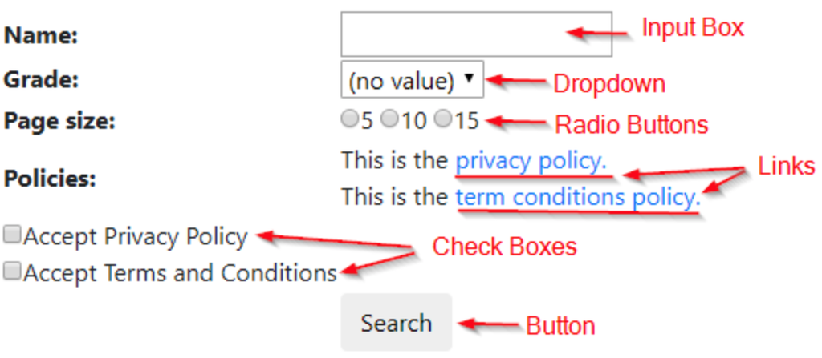

- To process web forms, we need to first find these web elements and then take subsequent actions on them like selecting a value or entering some text.
- Selenium performs actions on the web form and interacts with the form.

## Filling in web forms

### Input box

- (1)
- (2)
- (3)
- To handle any input box, we must be able to enter information, clear information or get information from the box.
  - To enter text into an input box we can use the `send_keys()` method.

```python
url = "https://qavbox.github.io/demo/signup/"
driver.get(url)

driver.find_element(By.ID, 'username').send_keys("YOUR_NAME")
```

- If we need to validate some existing text, we can fetch text already in a text box using the `get_attribute()` method:

```python
nameText = driver.find_element(By.ID, 'username').get_attribute("value")
```

- To clear pre-entered text, we can use the `clear()` method.

```python
driver.find_element(By.ID, 'username').clear()
```

## Filling in web forms

### Dropdown

- (1)
- (2)
- (3)
- A dropdown provides a list of options to the user, thereby giving access to one or multiple values as per the requirement.
- The Selenium Python API provides the `Select` class, which allows us to select the element of our choice from a dropdown menu.
- Note that the `Select` class only works with tags that have `<select>` tags.
- We can select a sub-element of the dropdown using:
  1. `index`;
  2. `value`;
  3. `text`.

```python
from selenium.webdriver.support.ui import Select
gender_dropdown = Select(driver.find_element(By.NAME, "sgender"))
gender_dropdown.select_by_index(2)
gender_dropdown.select_by_value("female")
gender_dropdown.select_by_visible_text("Male")
```

- In a similar way, we can deselect any selected value from the dropdown using any of the following options:
  1. `deselect_by_index()`
  2. `deselect_by_value`
  3. `deselect_by_visible_text`

## Filling in web forms

### Radio button

- (1)
- `is_selected()`
- `get_attribute("checked")`
- A radio button is a circular element on the screen that we can select.
  - It is only possible to select one radio button out of several choices by the `click()` method.
- To get the current state of the radio button we can use one of two methods: `is_selected()` or `get_attribute("checked")`

```python
driver.find_element(By.XPATH, '//*[@id="container"]/div[8]/input[1]').click()
yr_exp_boolean = driver.find_element(By.XPATH, '//*[@id="container"]/div[8]/input[1]').is_selected()
print(yr_exp_boolean)
print(type(yr_exp_boolean))
```

```python
yr_exp_boolean2 = driver.find_element(By.XPATH, '//*[@id="container"]/div[8]/input[1]').get_attribute("checked")
print(yr_exp_boolean2)
print(type(yr_exp_boolean2))
```

## Filling in web forms

### Check box

- (1)
- `is_selected()`
- `get_attribute("checked")`
- To select or check a value in a check box we use the `click()` method.
  - To get the current state of the check box we can use one of two methods: `is_selected()` or `get_attribute("checked")`
  - It is also possible to de-select check boxes.

```python
driver.find_element(By.XPATH, '/html/body/form/fieldset/div/div/div[9]/input[1]').click()
skills_boolean = driver.find_element(By.XPATH, '/html/body/form/fieldset/div/div/div[9]/input[1]').is_selected()
print(skills_boolean)
print(type(skills_boolean))
```

```python
skills_boolean = driver.find_element(By.XPATH, '/html/body/form/fieldset/div/div/div[9]/input[4]').get_attribute("checked")
print(skills_boolean)
print(type(skills_boolean))
```

## Filling in web forms

### Button

- Buttons are simply used to submit whatever information we have filled in our forms to the server.
  - This can be done through click actions on the button, mostly using the `click()` method:

```python
driver.find_element(By.ID, "submit").click()
```

## FYI on Web-scrapping Approaches

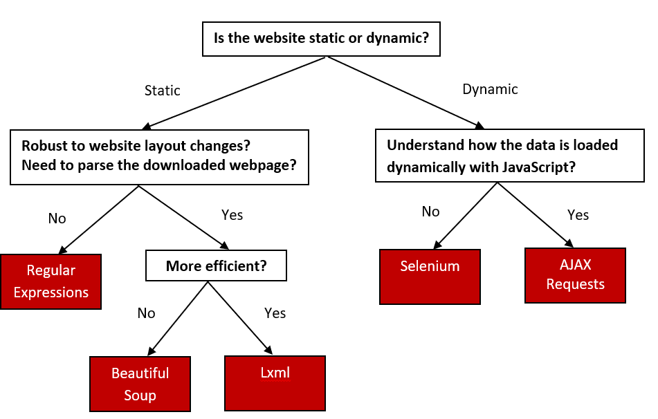